# Cadeias de Markov e Introdução a MCMC

Aishameriane Schmidt

Última atualização: 08 abril 2018

$$\begin{align*}
\newcommand{\norm}[1]{\left\lVert#1\right\rVert}
\end{align*}$$

- Capítulo 7 de (Paulino, Amaral., and Murteira 2003)
- Seção 6.2.2 de (C. P. Robert 2007)
- Seção 3.3 de (C. Robert and Casella 1999)
- Capítulo 6 de (C. Robert and Casella 2010)
- Capítulo 3 de (Bauwens, Lubrano, and Richard 2000)
- Capítulo 1 de (Meyn and Tweedie 2012)
- Capítulos 5, 6 e 7 de (Greenberg 2008)
- Capítulo 1 e 2 de (Karlin and Taylor 1975)
- (Chib 2001)
- (Chib 2013)

# Carregando os pacotes

```r
chooseCRANmirror(graphics = FALSE, ind = 10)
if (!require("pacman")) install.packages("pacman")
pacman::p_load(ggplot2, gridExtra, latex2exp, RColorBrewer, ggfortify,reshape2)
```

# Dúvidas

1. **Dúvida 1:** Na seção 6.3 do Greenberg, a equação que está entre 6.8 e 6.9 é uma versão do Chapman-Kolmogorov que dá a probabilidade de ir de $y$ em $n-1$ para $x$ em $n$?

**Resposta:**

2. **Dúvida 2:** Na página 86 do (Greenberg 2008) tem o seguinte: $P_X(X_n \ \in \ B i.o.) = 1, \ \text{for} \ \pi\text{-almost all}\ x$. Eu não entendi o que isso quer dizer… Obs: A definição do *i.o.* está na página 83, onde ele diz que significa *infinetely often*.

**Resposta:** para entender isso, precisamos da definição abaixo: **Definição ($\pi$ quase sempre)**: Seja um espaço de probabilidade $(\Omega, \mathcal{B}, \mathbb{P})$. Dizemos que uma propriedade $A(X),\ x \in \Omega$ vale $\mu$ quase sempre se $\mu(\{X \in \Omega |A(X)\text{ é verdadeira} \})=1$, em que $\mu$ é uma medida de probabilidade.

3. **Dúvida 3:** Entre o teorema 6.4 e o teorema 6.5 (página 84) o Greenberg faz um papo de que embora a teoria de cadeias de Markov tratem de, a partir de uma probabilidade de transição $P$, encontrar quem é a densidade estacionária $\pi$, quando trabalhamos com MCMC a gente quer o contrário, isto é, sabemos quem é $\pi$ e queremos chegar em uma $P$. Mas daí depois de falar isso ele apresenta o teorema 6.5 mas ele começa tendo uma $P$ fixa e eu esperava que ele iajustamente mostrar como sair de $\pi$ e chegar na $P$. Tô doida ou de fato o parágrafo não tá muito relacionado com o teorema? Aí entra um segundo pedaço dessa dúvida. Quando fazemos MCMC seria como, usando o exemplo da aula, dizer: *preciso amostrar de $\mathcal{N}\left(\frac{a}{1-b}, \frac{d^2}{1-b^2} \right)$, ache uma cadeia de Markov que converge pra isso!* E daí a gente magicamente tira do bolso $X_t = a + b\cdot X_{t-1} + d\cdot u_{t}$?

**Resposta:**

# Métodos de Monte Carlo

## Ideias básicas da integração de Monte Carlo

- Métodos de Monte Carlo são uma alternativa para resolução de integrais (especialmente em casos multivariados onde a dimensão do problema torna os algoritmos não estocásticos muito lentos);
- Uma vez que a abordagem bayesiana requer o cálculo de distribuições a posteriori que muitas vezes envolve a resolução de integrais, os algorítmos de MC acabam sendo muito úteis neste contexto;
- MC é baseado na ideia de reamostrar valores de uma distribuição de probabilidade (simulação estocástica). Utilizando um gerador de números pseudo-aleatórios podemos obter valores de qualquer distribuição (através da $F^{-1}(\cdot)$)

## Método

Considere a seguinte integral:

$$\begin{equation}\tag{01}
\int g(\theta)h(\theta|x)d\theta = \mathbb{E}[g(\theta)|x]
\end{equation}$$

Podemos ainda nos utilizar da probabilidade condicional $f(x|\theta) = \frac{f_{X,\theta}(x,\theta)}{\pi(\theta)} \Rightarrow f_{X,\theta}(x,\theta) = f(x|\theta)\pi(theta)$ para reescrever $h(\theta|x) = \frac{f(x|\theta)\pi(theta)}{f_{X}(x)}$. Como o denominador é uma constante, podemos simplesmente definir o problema da integral acima da seguinte maneira:

$$\begin{equation}\tag{02}
\int_{\Theta} g(\theta)f(x|\theta)\pi(\theta)d\theta
\end{equation}$$

A primeira forma é como está definido o problema em (Paulino, Amaral., and Murteira 2003) (página 286) e a segunda é como está em (C. P. Robert 2007) (página 294).

(Paulino, Amaral., and Murteira 2003) Se pudermos simular uma amostra $\theta_1, \ldots, \theta_n$ da densidade *a posteriori* $h(\theta|x)$, o método de MC irá aproximar por uma média amostral:

$$\begin{equation}\tag{03}
\hat{\mathbb{E}}[g(\theta)|x] = \frac{1}{n}\sum_{i=1}^n g(\theta_i)
\end{equation}$$

Utilizando a lei dos grandes números, pode-se demonstrar que (03) converge quase certamente para a média $\mathbb{E}[g(\theta)|x]$ dada em (01). O método nos diz que se conseguirmos amostras da distribuição *a posteriori* $h(\theta|x)$, podemos resolver as integrais da forma descrita em (01).

(C. P. Robert 2007) Se for possível obter valores $\theta_1, \ldots, \theta_n$ da distribuição $\pi(\theta)$, então a média amostral

$$\begin{equation}\tag{04}
\frac{1}{n}\sum_{i=1}^m g(\theta_i)f(x|\theta_i)
\end{equation}$$

converge quase certamente para a média dada em (02) quando $m \to \infty$, pela lei dos grandes números. De maneira similar, se uma amostra aleatória de $\theta_i$’s da distribuição $\pi(\theta|x)$ pode ser obtida, então

$$\begin{equation}\tag{05}
\frac{1}{n}\sum_{i=1}^m g(\theta_i)
\end{equation}$$

converge para

$$\begin{equation}\tag{06}
\frac{\int_{\Theta g(\theta)f(x|\theta)\pi(\theta)d\theta}}{\int_{\Theta} f(x|\theta)\pi(\theta)d\theta}
\end{equation}$$

# Uma (não tão) breve introdução aos processos estocásticos e Cadeias de Markov

A teoria de processos estocásticos se ocupa de investigar a estrutura de famílias de variáveis aleatórias $\{X_\theta \}$ indexadas por um parâmetro $\theta$, em que $\theta \in \Theta$ ($\Theta$ é chamado de conjunto indexador). Em praticamente todas as aplicações, $\Theta$ representa o tempo. A *realização* de um processo estocástico $\{X_\theta, \theta \in \Theta \}$ é quando associamos, a cada $\theta \in \Theta$, um dos possíveis valores de $X_\theta$. Por exemplo, no caso de $\theta$ assumir valores discretos (quando $\Theta=\{0, 1,2, 3, \ldots \}$) e $X_\theta$ representar o resultado de uma moeda ($1$ para cara e $0$ para coroa), então a sequência $01001101110001111110$ é uma realização possível deste processo estocástico considerando $20$ lançamentos da moeda. Os valores de $X_\theta$ podem ser unidimensionais, bidimensionais, $n$-dimensionais ou terem uma estrutura mais geral ainda. No caso onde $X_n$ é o resultado do lançamento de um dado, seus valores possíveis pertencem ao conjunto $\{1,2,3,4,5,6 \}$ e uma realização do processo poderia ser $5,1,3,2,2,4,1,6,3,6,\ldots$. Nestes dois exemplos, as variáveis aleatórias são independentes, porém essa não é a regra quando lidamos com processos estocásticos (Karlin and Taylor 1975).

Os principais elementos que distinguem os processos estocásticos são o *estado de espaços*, o *parâmetro indexador* e a natureza da relação entre as variáveis aleatórias $X_t$. Essas classificações foram retiradas de (Karlin and Taylor 1975), sendo que aqui iremos nos preocupar apenas com as duas primeiras classificações.

Uma Cadeia de Markov $\{\theta^{(t)}\}$ é uma sequência de variáveis aleatórias não-independentes $\theta^{(0)}, \theta^{(1)}, \theta^{(2)}, \ldots, \theta^{(t)}, \ldots$ tais que a densidade de probabilidade de $X^{(t+1)}$ condicional aos valores passados depende apenas de $\theta^{(t)}$, isto é, uma Cadeia de Markov tem como característica sua ``perda de memória’’ *exceto* com relação ao passado imediatamente anterior (Meyn and Tweedie 2012). Posto de outra maneira, um *processo Markoviano* é um processo com a propriedade de que, dado o valor $X_t$, o valor de $X_s$, $s > t$, não depende dos valores de $X_u$, $u < t$, ou seja, a probabilidade do comportamento futuro do processo, quando o estado atual é totalmente conhecido, não depende de informações adicionais a respeito das informações passadas. Formalmente, um processo é dito ser Markoviano se
$$\begin{align*}
\mathbb{P}(a < X_t \leq b| X_{t_1}) &= x_1, X_{t_2} = x_2, \ldots, X_{t_n} = x_n)\\
&= \mathbb{P}(a < X_t \leq b|X_{t_n} = x_n)
\end{align*}$$

sempre que $t_1 < t_2 < \ldots < t_n < t$.

A probabilidade condicional de $\theta^{(t+1)}$ dado os valores anteriores é chamada de *núcleo de transição* (do inglês *transition kernel*) ou *núcleo de Markov* ( *Markov Kernel* ) e é denotado por $K$:
$$\theta^{(t+1)}\ |\ \theta^{(0)}, \theta^{(1)}, \theta^{(2)}, \ldots, \theta^{(t+1)} \sim K\left(\theta^{(t)}, \theta^{(t+1)}\right).$$
Se pensarmos na cadeia de Markov como uma sequência de v.a. que evoluem ao longo do tempo, o núcleo de transição é a probabilidade de mudança de um estado para outro (ainda nesta seção será dada uma definição alternativa, fornecida pelo texto do (Greenberg 2008)), condicional ao estado atual. Formalmente, temos:

Quando $\Theta$ é discreto, então o núcleo de transição é simplesmente a matriz de transição $K$ com elementos dados por

$$\mathbb{P}_{mn} = \mathbb{P}\left(\theta^{(t+1)} = n|\theta^{(t)} = m\right), \qquad m,n \in \Theta$$
e, por múltiplos produtos, temos $\theta^{(t)} \sim \mu_t = \mu \cdot K^t$.

Podemos então reescrever nossa definição de cadeia de Markov usando o núcleo de transição como segue.

**Definição 4.02** Cadeia de Markov (adaptado de (C. Robert and Casella 1999)) Dado um núcleo de transição $K$, uma sequência $X_0, X_1, \ldots, X_n, \ldots$ de variáveis aleatórias é uma cadeia de Markov, denotada por $\{X_n \}$, se, para qualquer $t$, a distribuição condicional de $X_t$ dado $x_{t-1}, x_{t-2}, \ldots, x_0$ é a mesma que a distribuição de $X_t$ dado $x_{t-1}$, isto é:
$$\begin{align*}
\mathbb{P}(X_{k+1} \in A | x_0, x_1, x_2, \ldots, x_k) &= \mathbb{P}(X_{k+1} \in A | x_k)
&= \int_A K(x_k, dx)
\end{align*}$$

Uma notação alternativa é dada por (Greenberg 2008). Considere um processo estocástico indexado por $t$ e denotado por $X_t$, que toma valores em um conjunto finito $S = \{1,2, \ldots, s \}$. O índice $t$ pode ser interpretado como o instante de tempo ou a iteração. Para qualquer para de inteiros, $i, j \ \in S$, definimos $p_{ij}$ como a probabilidade que $X_{t+1} = j$ dado que $X_t = i$, isto é
$$p_{ij} = \mathbb{P}(X_{t+1} = j | X_t = i), \ \forall i,j \ \in S$$
. E dizemos que $p_{ij}$ são as probabilidades de transição. A hipótese de que a distribuição de probabilidade no tempo $t+1$ depende apenas do estado do sistema no período $t$ é chamada de *propriedade Markoviana* e resulta em um processo estocástico chamado de *processo de Markov*.

Uma vez que $p_ij}$ são probabilidades, temos $p_{ij} \geq 0$. Mais ainda, como o processo fica restrito a $S$, temos
$$\sum\limits_{j=1}^s p_{ij} = 1$$
(isso implica que a soma das probabilidades do sistema sair da posição $i$ e ir para qualquer outra posição é sempre $1$). Será conveniente também definir a *matriz de transição* de dimensão $s \times s$ e denotada por $P = \{p_{ij} \}$. A $i$-ésima linha de $P$, $(p_{i1}, p_{i2}, \ldots, p_{is})$ especifica a distribuição do processo $t+1$, dado que está no estado $i$ no tempo $t$.

Por exemplo, a matriz de transição abaixo
$$\tag{01}
P =
\begin{pmatrix}
0.750 & 0.250 \\
0.125 & 0.875
\end{pmatrix}$$
especifica que o processo permanece no estado $1$ com probabilidade $.750$ e se move para o estado $2$ com probabilidade $.250$ (caso comece no estado $1$). Analogamente, se o sistema começa no estado $2$, existe uma probabilidade de $87.5\%$ de continuar nesse estado e $12.5\%$ de mudar para o estado $1$.

Na maioria das aplicações MCMC, as cadeias de Markov construídas possuem um comportamento estável. De fato, essas cadeias têm, por construção uma distribuição de probabilidade estacionária (**Obs:**É preciso tomar cuidado para não confundir a existência de uma distribuição estacionária com o conceito de estacionariedade (estrita). No livro de (Karlin and Taylor 1975) diz o seguinte: *A Markov process is said to have stationary transition probabilities if $P(x, s; t, A)$ (a probabilidade de transição) is a function only of $t-s$. Remember that $P(x, s; t, A)$ is a conditional probability, given the present state. Therefore,* *there is no reason to expect that a Markov Process with stationary transition probabilities is a stationary process, and this is indeed the case.*) Um exemplo de processo de Markov que não é estacionário é o movimento Browniano.} (ou simplesmente , do inglês *stationary probability distribution*). Isso significa que existe uma distribuição de probabilidade $f$ tal que se $\theta^{(t)} \sim f$, então $\theta^{(t+1)} \sim f$. Formalmente, a relação entre o núcleo de transição e a distribuição estacionária de uma cadeia de Markov é que eles satisfazem
$$\int_\Theta K\left(\theta^{(t)},\theta^{(t)}\right)f\left(\theta^{(t)}\right)d\theta^{(t)} = f\left(\theta^{(t+1)}\right).$$

De acordo com (C. Robert and Casella 2010), a existência da distribuição estacionária (ou a propriedade de estacionariedade da cadeia) impõe uma restrição prévia em $K$ chamada de *irredutibilidade* (*irreducibility*) na teoria das cadeias de Markov, que significa que o núcleo $K$ permite ‘’movimentos livres’‘em todo o espaço de parãmetros. Ou seja, não importa o valor inicial de $\theta^{(0)}$, a sequência $\{\theta^{(t)} \}$ tem uma probabilidade não nula de eventualmente chegar em qualquer valor do espaço de parâmetros (uma condição suficiente é que $K(\theta^{(t)}, \cdot) > 0, \ \forall \ t)$. A existência de uma distribuição estacionária implica que as cadeias de Markov são’‘recorrentes’’, i.e., a cadeia assume valores em todos subconjuntos do espaço paramétrico um número infinito de vezes.

Na notação do (Greenberg 2008), antes de definir a distribuição estacionária, vamos voltar para a matriz $P$ dada em (1). Inicialmente, considere a distribuição do estado em $t+2$, dado que o sistema encontra-se em $i$ no tempo $t$. Essa distribuição é denotada por $p_{ij}^{(2)}$ e pode ser calculada da seguinte forma: para ir do estado $i$ para o estado $j$ em dois passos, o processo vai de $i$ no tempo $t$ para qualquer outro estado $k$ em $t+1$ e então vai de $k$ até $j$ em $t+2$. Essa transição ocorre com a seguinte probabilidade:

$$p_{ij}^{(2)} = \sum_k p_{ik}\cdot p_{kj}\tag{02}$$
Isso acontece porque precisamos considerar todos os possíveis $k$ para chegar até $j$. Por exemplo, na matriz (01), supondo que estamos no estado 1, podem acontecer duas coisas no primeiro instante de tempo: 1) permanecer no estado $1$ com probabilidade $0.750$ ou 2) passar para o estado $2$ com probabilidade $0.250$. Se ocorrer 1), então necessariamente no próximo instante de tempo precisaremos passar para o estado $2$. Essa primeira possibilidade ocorre com probabilidade $0.750 \times 0.250$= 0.1875. Já na outra possibilidade, precisaremos que ele permaneça no estado $2$, então isso ocorre com probabilidade $0.250 \times 0.875=$ 0.21875. A probabilidade de sair do estado $1$ no tempo $2$ para o estado $2$ no tempo $2$ será a soma dessas duas probabilidades:0.40625. Isto é, se olharmos na equação (02), nosso $k$ assume valores $1$ e $2$, $i=1$ e $j=2$. O que acontece se multiplicarmos a matriz $P$ por ela mesma?

$$\begin{align}
P \times P &=
\begin{pmatrix}
0.750 & 0.250 \\
0.125 & 0.875
\end{pmatrix} \times
\begin{pmatrix}
0.750 & 0.250 \\
0.125 & 0.875
\end{pmatrix}\nonumber\\
&= \begin{pmatrix}
0.750^2 + 0.250 \times 0.125 & 0.750\times 0.250 + 0.250 \times 0.875 \\
0.125\times 0.750 + 0.875\times 0.125 & 0.125\times 0.250 + 0.875^2
\end{pmatrix}\\
&= \begin{pmatrix}
0.5938 & 0.4062 \\
0.2031 & 0.7969
\end{pmatrix}
\end{align}$$

Note que o valor que está na primeira linha e segunda coluna, $0.4062$ é justamente a probabilidade de iniciar o sistema na posição $1$ e terminar na posição $2$ em $t=2$. Este resultado é esperado, uma vez que a matriz de $p_{ij}^{(2)}$ é dada por $P\cdot P \equiv P^2$. Isso decorre da própria definição de produto matricial. Suponha que $C = A \times B$, com $A$ e $B$ $2\times2$. Então:

$$\begin{align*}
C = A \times B &=
\begin{pmatrix}
a_{11} & a_{12} \\
a_{21} & a_{22}
\end{pmatrix} \times
\begin{pmatrix}
b_{11} & b_{12} \\
b_{21} & b_{22}
\end{pmatrix}\\
&= \begin{pmatrix}
a_{11}\cdot b_{11}+a_{12}\cdot b_{21} & a_{11}\cdot b_{12}+ a_{12}\cdot b_{22} \\
a_{21}\cdot b_{11}+a_{22}\cdot b_{21} & a_{21}\cdot b_{12}+ a_{22}\cdot b_{22}
\end{pmatrix}\\
&= \begin{pmatrix}
\sum_{k=1}^2 a_{1k}b_{k1} & \sum_{k=1}^2 a_{1k}b_{k2} \\
\sum_{k=1}^2 a_{2k}b_{k1} & \sum_{k=1}^2 a_{2k}b_{k2}
\end{pmatrix}.
\end{align*}$$

É possível, usando indução, demostrar que os valores de $p_{ij}^{(n)}$ são as entradas $ij$ da matriz $P^n$ (com $n \in \mathbb{N}$). Será conveniente definir $p_{ij}^{(0)}$ como $1$ se $i=j$ e $0$ caso contrário. Vamos agora ver algumas definições básicas e exemplos.

*Acessibilidade, comunicatividade*: Se $p_{ij}^{(n)}>0$ para algum $n\geq 1$, dizemos que $j$ é acessível a partir de $i$ e escrevemos $i \rightarrow j$. Caso $i \rightarrow j$ e $j \rightarrow i$, dizemos de $i$ e $j$ se comunicam e escrevemos $i \leftrightarrow j$. Pode-se mostrar que a relação de comunicação entre estados define uma relação de equivalência, isto é, $i \leftrightarrow i$ (reflexibilidade), $i \leftrightarrow j \Longleftrightarrow j \leftrightarrow i$ (simetria) e se $i \leftrightarrow j$ e $j \leftrightarrow k$, então $i \leftrightarrow k$ (transitividade). Uma prova pode ser vista em [Karlin and Taylor (1975)}.

A relação de equivalência define como as classes dentro dos estados se comunicam. Uma ideia importante da teoria agora pode ser definida: um processo de Markov é dito *irredutível* se há apenas uma classe de equivalência, isto é, se todo mundo se comunica com todo mundo (caso houvesse $2$ classes de equivalência, haveriam dois grupos onde todo mundo de cada grupo se comunica, porém os grupos não tem ligação entre si). Isso é equivalente a dizer que partindo de um estado $i$ o processo pode parar em qualquer outro estado com probabilidade não nula disso acontecer.

Um exemplo de matriz $P$ de um processo não irredutível é dada por:
$$\begin{align}\tag{02}
P_R &=
\begin{pmatrix}
P_1 & 0 \\
0 & P_2
\end{pmatrix}.
\end{align}$$

em que $P_1$ e $P_2$ são de dimensão $m\times m$. Se o processo começar em qualquer um dos $m$ primeiros estados (ou seja, em $P_1$), ele nunca sairá de $P_1$. Da mesma forma, se o processo começa em $P_2$, ele nunca sairá de $P_2$.

Outra propriedade importante de uma cadeia é a *peridiocidade*. Considere uma matriz de transição que assume a seguinte forma:
$$\begin{align}\tag{02}
P_P &=
\begin{pmatrix}
0 & P_1 \\
P_2 & 0
\end{pmatrix}.
\end{align}$$

em que $P_1$ e $P_2$ são de dimensão $m\times m$. Se em $t=1$ o processo está em um dos primeiro $m$ estados, então ele necessariamente irá para $m+1, m+2$ ou $2m$. Analogamente, em $t=3$, o processo terá que voltar para os primeiros $m$ estados e assim por diante. Isto significa que a série retorna a um estado apenas nos valores de $n$ pares e neste caso dizemos que o período da cadeia é $2$. Se o período é igual a $1$ para todos os estados, a cadeia é dita ser *aperiódica*. Mais formalmente, se $i \rightarrow i$, então o $i$ é o maior divisor comum dos inteiros no conjunto $A = \{n \geq 1: p_{ii}^{(n)} > 0\}$. Em palavras, se $d_i$ é o período de $i$, então $p_{ii}^{(n)}=0$ sempre que $n$ não for um múltiplo de $d_{i}$, e $d_i$ é o maior inteiro com esta propriedade. Note que uma cadeia é aperiódica se $p_{ii}^{(n)}>0$ para todo $i$ para um valor de $n$ suficientemente largo.

A distribuição de probabilidade $\pi = (\pi_1, \ldots, \pi_s)'$ é dita ser a *distribuição invariante* de $P$ se $\pi' = \pi'P$ ou,
$$\begin{equation}\tag{6.3}
\pi_j = \sum\limits_i \pi_i p_{ij}, \qquad j = 1, \ldots, s.
\end{equation}$$

O lado direito da equação é a probabilidade do processo estar no estado $j$ em qualquer $t$ marginalizado sobre os estados $t-1$, ele pode ser interpretado como a probabilidade de iniciar o processo no estado $i$ com probabilidade $\pi_i$ e então se mover para o estado $j$ com probabilidade $p_{ij}$. O fato de que o valor resultante é $pi_j$ é o que faz de $\pi$ uma distribuição invariante: se os estados são escolhidos de acordo com $\pi$, a probabilidade é $\pi_j$ de que o sistema esteja em um estado $j$ a qualquer período de tempo. Note ainda que $\pi'$ é o vetor característico da matriz $P$ com raiz característica igual a $1$.

Vamos descobrir quem é a distribuição invariante da matriz $P$ dada em (1), utilizando a relação $\pi'P=\pi'$:

$$\begin{align*}
(\pi_1, \pi_2)\begin{pmatrix}
0.750 & 0.250 \\
0.125 & 0.875
\end{pmatrix} &= (\pi_1, \pi_2) \\
0.750 \cdot \pi_1 + 0.125 \cdot \pi_2 = \pi_1.
\end{align*}$$

Agora, usamos o resultado que $\pi_2 = 1 - \pi_1$ para obter
$$\pi_1 = 0.750\cdot \pi_1 + 0.125(1-\pi_1) \rightarrow 0.375 \cdot \pi_1 = 0.125 \rightarrow \pi_1 = \frac{1}{3},$$
o que implica que $\pi = (1/3, 2/3)$.

A existência e unicidade das distribuições invariantes são um aspecto importante da teoria. Em particular, irredutibilidade é uma condição necessária para que $P$ tenha uma distribuição invariante única. Um caso especial de uma cadeia de markov irredutível e aperiódica é dado por aquela onde $p_{ij}>0$. Neste caso, o seguinte teorema é válido:

**Teorema 1** (adaptado de (Greenberg 2008), página 79)

Suponha que o espaço de estados $S$ é finito e $p_{ij}>0 \ \forall \ i,j$. Então, existe uma única distribuição de probabilidade $\pi_j$, $j\in S$, tal que $\sum_i \pi_i p_{ij} = \pi_j \ \forall\ j \in S$. Mais ainda,
$$|p_{ij}^{(n)} - \pi_j| \leq r^n,$$
em que $0 < r < 1$, para todo $i, j$ e $n \geq 1$.

De acordo com (Greenberg 2008). este teorema nos diz que, em um estado de espaços finito onde todas probabilidades são positivas, não apenas existe uma única distribuição invariante, $\pi_j$, como também as probabilidades de transição $p_{ij}^{(n)}$ convergem a uma taxa geométrica ($r^n$) para $\pi_j$. Note que este último resultado, para valores suficientemente grandes de $n$, independe do estado inicial $i$. Outra maneira de dizer isso é que $P^n$ converge para uma matriz onde as linhas são dadas por $\pi'$.

Vamos voltar na nossa matriz dada em (1) e calcular $P^{10}$ e $P^{20}$:

$$\begin{align*}
P^{10} = \begin{pmatrix}
0.339 & 0.661 \\
0.330 & 0.670
\end{pmatrix} & \qquad
P^{20} = \begin{pmatrix}
0.333 & 0.667 \\
0.333 & 0.667
\end{pmatrix}.
\end{align*}$$

Observe que $P^n$ alcança sua distribuição invariante (até pelo menos a terceira casa decimal) quando $n=20$ (nem foi necessário chegar em $n=30$, o infinito!).

O teorema (1) forma a base dos métodos de MCMC. Ele nos diz que se uma cadeia de Markov satisfaz certas condições, a distribuição de probabilidade de sua $n$-ésima iteração é, para $n$ grande, muito próxima da distribuição invariante. Posto de outra forma, as retiradas $n+1$, $n+2$, etc, para $n$ grande serão amostradas da distribuição invariante. Em termos de simulação, isso implica que se conseguirmos encontrar um processo de Markov para o qual a distribuição invariante é a nossa distribuição alvo, podemos simular retiradas do processo estocástico para gerar valores da distribuição que temos interesse.

Um exemplo de processo e distribuição invariante é o exercício 6.1 de (C. Robert and Casella 2010), detalhado a seguir.

**Exercício 6.1** (retirado de (C. Robert and Casella 2010))

Considere a cadeia de Markov definida por $X^{(t+1)} = \rho X^{(t)} + \epsilon_t$, com $\epsilon_t \sim \mathcal{N}(0,1)$. Simule $X^{(0)} \sim \mathcal{N}(0,1)$ e plote o histograma de uma amostra de $X^{(t)}$ para $t \leq 10^4$ e $\rho = 0.9$. Verifique a aderência da distribuição estacionária $\mathcal{N}\left(0,\frac{1}{(1-\rho^2)}\right)$.

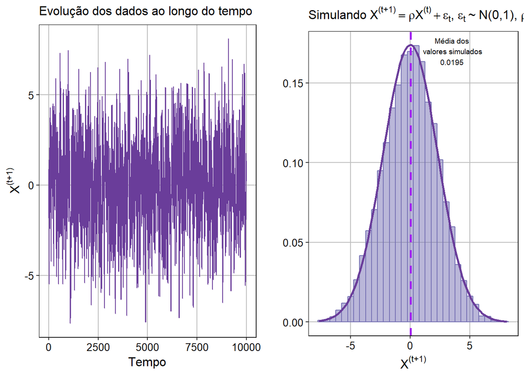

```r
# Define a semente
set.seed(6969)

# Define o t máximo
tamanho <- 10^4

# Define o valor de rho
rho <- 0.9

# Amostra o valor inicial
X_0 <- rnorm(0,1,n = 1)

# Cria uma cadeia vazia
cadeia <- vector()
cadeia[1] <- X_0

# Popula a cadeia
for (i in 2:tamanho){
  cadeia[i] <- rho*cadeia[i-1]+rnorm(0,1,n=1)
}

cores <- brewer.pal(6, "Dark2")
cores2 <- brewer.pal(10, "Paired")
cadeiadf <- data.frame(1:tamanho, cadeia)

# Plot os the time series
p1 <- autoplot(as.ts(cadeia), main = "Evolução dos dados ao longo do tempo", xlab = "Tempo", ylab = TeX('X^{(t+1)}'), colour = cores2[10]) +
  theme(plot.title=element_text(size = 12),
              text=element_text(size = 12),
              axis.text.x=element_text(colour="black", size = 10),
              axis.text.y=element_text(colour="black", size = 10),
              panel.background = element_blank(),
              panel.grid.major = element_line(colour = "gray"),
              panel.grid.minor = element_line(),
              panel.border = element_rect(colour = "black", fill = NA))

# Histogram overlaid with kernel density curve
p2 <- ggplot(cadeiadf, aes(x=cadeiadf$cadeia)) +
    geom_histogram(aes(y=..density..),      # Histogram with density instead of count on y-axis
                   binwidth=.5, fill = cores[3], colour = cores[3], alpha=0.5)+
   stat_function(
     fun = function(x, mean, sd, n, bw){
       dnorm(x =x, mean = mean, sd = sd)
   },
   args = c(mean = 0, sd = 1/sqrt(1-rho^2), n = length(cadeia), bw = .5), colour = cores2[10], size = 1)+
  labs(title= TeX('Simulando $X^{(t+1)}=\\rho X^{(t)} + \\epsilon_t$, $\\epsilon_t \\sim N(0,1)$, $\\rho = .9$'), y = "", x= TeX('$X^{(t+1)}$'), color = "Variável") +
    theme(plot.title=element_text(size = 12),
              text=element_text(size = 12),
              axis.text.x=element_text(colour="black", size = 10),
              axis.text.y=element_text(colour="black", size = 10),
              panel.background = element_blank(),
              panel.grid.major = element_line(colour = "gray"),
              panel.grid.minor = element_line(),
              panel.border = element_rect(colour = "black", fill = NA))
p2 <- p2 + geom_vline(aes(xintercept=mean(cadeia)),
            color="purple", linetype="dashed", size=1) + annotate("text", x = 3.5, y = 0.17, label = paste0("Média dos\n valores simulados\n", round(mean(cadeia),4)), size = 2.5)

#pdf(file="C:\\Users\\Aishameriane\\OneDrive\\Documentos\\Mestrado Economia\\Bayesiana - 2018-01\\Notas de Aula 2018\\Imagens notas de aula\\Cap 4\\Fig-4.007.pdf", width = 10, height = 4)
grid.arrange(p1, p2, ncol = 2, nrow = 1)
```

```r
#dev.off()
```

No histograma foi plotada a distribuição $\mathcal{N}\left(0, \frac{1}{1-\rho^2}\right)$, por ser a distribuição estacionária da cadeia. Para verificar, vamos calcular a média e a variância, assumindo $X^{(t+1)} = X^{(t)}$:

$$\begin{align*}
\mathbb{E}[X^{(t+1)}] &= \mathbb{E}[\rho X^{(t)} + \epsilon_t]\\
\mathbb{E}[X] &= \mathbb{E}[\rho X + \epsilon_t]\\
\mathbb{E}[X] &= \rho\mathbb{E}[X] + \mathbb{E}[\epsilon_t]\\
(1-\rho)\mathbb{E}[X] &= 0\\
\mathbb{E}[X] &= 0
\end{align*}$$

Se a média é $0$, temos $Var[X] = \mathbb{E}[X^2] - (\mathbb{E}[X])^2 = \mathbb{E}[X^2] - (0)^2 = \mathbb{E}[X^2]$. Então:

$$\begin{align*}
\mathbb{E}[X^2] &= \mathbb{E}[(\rho X + \epsilon_t)^2]\\
\mathbb{E}[X^2] &= \mathbb{E}[(\rho X)^2 + 2\cdot\rho X\epsilon_t +\epsilon_t^2]\\
\mathbb{E}[X^2] &= \mathbb{E}(\rho X)^2 + 2\mathbb{E}(\rho X)\mathbb{E}(\epsilon_t) +\mathbb{E}(\epsilon_t^2)\\
\mathbb{E}[X^2] &= \rho^2 \cdot \mathbb{E}[X^2] + 0 + 1\\
(1-\rho^2)\mathbb{E}[X^2] &= 1\\
\mathbb{E}[X^2] &= \frac{1}{(1-\rho^2)}
\end{align*}$$

(C. Robert and Casella 2010) diz que no caso de cadeias recorrentes, a distribuição estacionária é dita também *distribuição limítrofe* (do inglês *limiting distribution* conferir essa tradução), pois a distribuição limite de $X^{(t)}$ é $f$ para quase todo valor inicial $X^0$. Essa propriedade também é conhecida como *ergodicidade* e é o que vai garantir os resultados obtidos com MCMC. Note que se um determinado núcleo (*kernel*) $K$ produz uma cadeia de Markov ergódica com distribuição estacionária dada por $f$, gerar uma cadeia a partir de $K$ irá eventualmente amostrar valores de $f$.

**Para refletir:** *Como mostrar que o passeio aleatório* $X^{(t+1)} = X^{(t)} + \varepsilon_{t+1}$ *não tem distribuição estacionária?* Bom, dá para perceber que a [variância incondicional depende do tempo](http://economia.unipv.it/pagp/pagine_personali/erossi/rossi_intro_stochastic_process_PhD.pdf), mas será que é o único jeito?

A restrição de que $p_{ij} > 0 \ \forall \ i,j$ do teorema (1) pode ser relaxada e o teorema generalizado da seguinte forma:

**Teorema 2** (adaptado de (Greenberg 2008), página 80) Seja $P$ irredutível e aperiódica em um espaço de estados finito. Então existe uma única distribuição de probabilidade $\pi$ tal que $\sum\limits_i \pi_i p_{ij} = \pi_j \ \forall \ j \ \in S$ e
$$|p_{ij}^{(n)}-\pi_j| \leq r^{\frac{n}{\nu}}$$
para todo $i$, $j$ $\in S$, em que $0 < r < 1$ e $\nu \in \mathbb{N}$.

(Greenberg 2008) não prova o teorema (ele indica o livro do [Bhattacharya e Waymire](https://www.amazon.com/Stochastic-Processes-Applications-Classics-Mathematics/dp/0898716896) página 128), mas propõe um exercício de verificar o que acontece quando as suposições do teorema não são atendidas. Considere a matriz de transição reduzível $P_R$, dada por (02). Ela não possui uma distribuição invariante única. Para notar isso, considere $\pi_1$ que satisfaz $\pi_1'P_1 = \pi_1'$ e $pi_2$ que satisfaz $\pi_2'P_2 = \pi_2'$ (isso pode ser feito por causa do teorema de Perron-Frobenius, que mostra que para uma matriz positiva quadrada sempre tem um vetor $\pi$ associado). Tome agora o vetor $(\pi_1 0)$. Então,
$$\begin{align*}
(\pi_1 \quad 0)\cdot
\begin{pmatrix}
P_1 & 0 \\
0 & P_2
\end{pmatrix}=
(\pi_1 \cdot P_R \quad 0)=
(\pi_1 \quad 0)
\end{align*}$$

(a mesma conta pode ser feita para $P_2$)

Então, $\pi' = (\pi_1 \quad 0)$ e $\pi'' = (0 \quad \pi_2)$ são distribuições invariantes de $P_R$. Mais ainda, podemos mostrar que todas as combinações convexas de $\pi'$ e $\pi''$ também serão distribuições invariantes, isto é, $\pi = (\omega\cdot pi_1,\ (1-\omega)\cdot\pi_2)$ é uma distribuição invariante de $P_R$. Note que $P_R$ não converge para nada útil para o procedimento de MCMC:

$$\begin{align*}
P_R^n = \begin{pmatrix}
P_1^n & 0 \\
0 & P_2^n
\end{pmatrix}
\end{align*}$$

Claramente $P_R^n$ não possui a mesma distribuição de probabilidade em todas as linhas.

Outra condição necessária é que a matriz seja aperiódica. Considere a matriz periódica e irredutível $P_P$ definida em (2) e vamos calcular $P_P^2$ e $P_P^3$:

$$\begin{align*}
P_P^2 = \begin{pmatrix}
P_1\cdot P_2 & 0 \\
0 & P_2 \cdot P_1
\end{pmatrix}\qquad
P_P^3 = \begin{pmatrix}
0 & P_1\cdot P_2 \cdot P_1\\
P_2 \cdot P_1 \cdot P_2 & 0
\end{pmatrix}
\end{align*}$$

Note que esse padrão irá se repetir indefinidamente, de forma que $P_P^n$ nunca terá a mesma distribuição em todas as linhas, não importa o valor de $n$. Isso não demonstra formalmente o teorema (2), mas pelo menos dá boas razões para que irredutibilidade e aperidiocidade sejam condições necessárias para que ele valha. O teorema (2) dá o resultado para que essas duas condições sejam suficientes para justificar os métodos MCMC em estado de espaços finitos, porém a maioria das aplicações em econometria envolve aplicações contínuas. O primeiro passo vai ser analisar cadeias de Markov com um número contável de estados antes de ir para as aplicações “pesadas”.

(aqui começa a seção 6.2 de (Greenberg 2008))

Um exemplo de espaço de estado contável é o passeio aleatório simples. Neste processo temos $S = \{0, \pm1, \pm2, \ldots \}$, e as probabilidades de transição são:

$$\begin{align*}
p_{ij} = \begin{cases}
p,&\ \text{se}\ j = i+1 \\
q,&\ \text{se}\ j = i-1 \\
0,&\ \textbf{caso contrário.}
\end{cases}
\end{align*}$$

em que $0 < p < 1$ e $q = 1-p$. Os possíveis estados são todos os inteiros positivos e negativos, i.e., $S$ é contável.

Irredutibilidade e aperidiocidade não mais vão implicar a existência de uma única distribuição quando $S$ é contável mas não finito. Iremos então usar o conceito de *recorrência*. Por exemplo, considere a cadeia de Markov definida pelas seguintes probabilidades de transição:

$$\begin{align*}
p_{ij} = \begin{cases}
p,&\ \text{se}\ j = i+1 \\
r,&\ \text{se}\ j = i \\
q,&\ \textbf{se}\ j = i-1
\end{cases}
\end{align*}$$

Este processo é um passeio aleatório. Partindo do estado $i$, ele se move para $i+1$ com probabilidade $p$, e se move com probabilidade $q$ para $i-1$. Além disso, ele pode ficar em $i$ com probabilidade $r$, sendo que $p+q+r =1$, com $p,\ q,\ r \geq 0$. Se todas as probabilidades são positivas, então o processo é irredutível e aperiódico (isto é, todos os estados se comunicam e todos os estados podem ser visitados). Uma forma de simular este processo é a seguinte (que utiliza $p=q=r$):

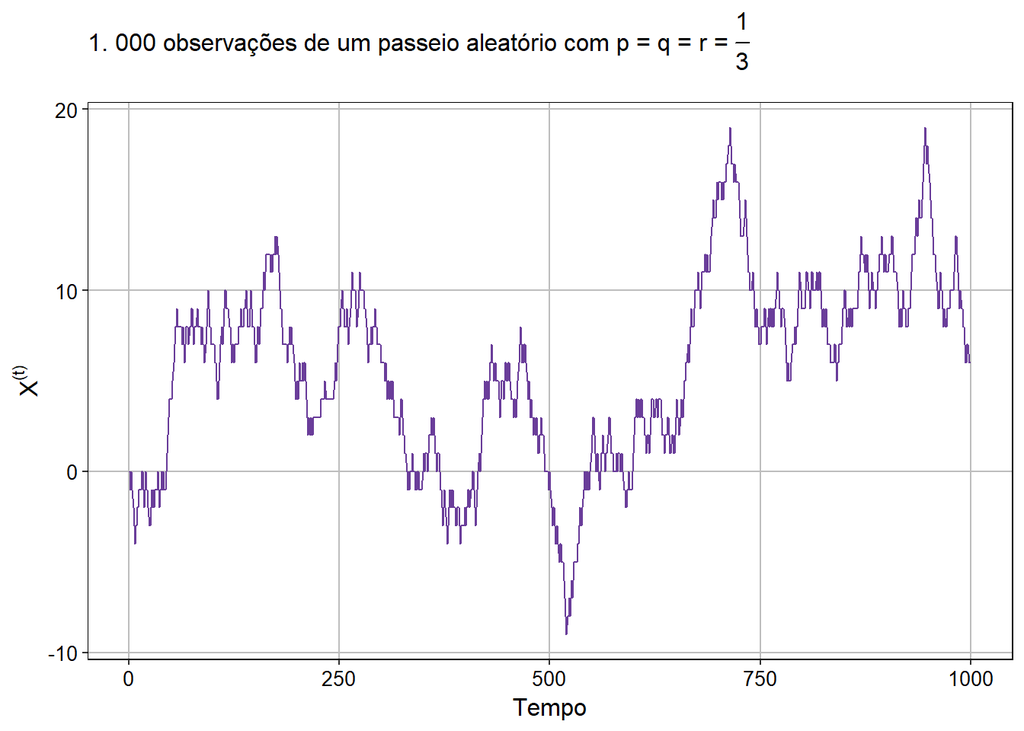

```r
set.seed(6969)

n <- 1000
x <- cumsum(sample(c(-1, 0, 1), n, TRUE))

p1 <- autoplot(as.ts(x), main = TeX('1.000 observações de um passeio aleatório com p = q = r = \\frac{1}{3}'), xlab = "Tempo", ylab = TeX('X^{(t)}'), colour = cores2[10]) +
  theme(plot.title=element_text(size = 12),
              text=element_text(size = 12),
              axis.text.x=element_text(colour="black", size = 10),
              axis.text.y=element_text(colour="black", size = 10),
              panel.background = element_blank(),
              panel.grid.major = element_line(colour = "gray"),
              panel.grid.minor = element_line(),
              panel.border = element_rect(colour = "black", fill = NA))

p1
```

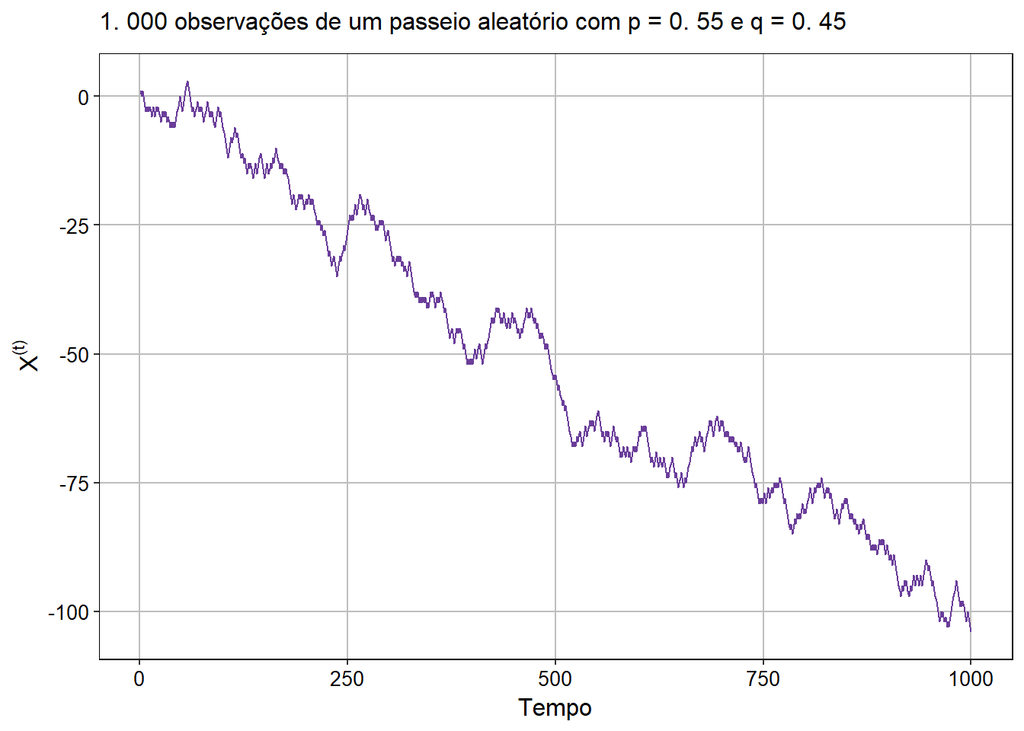

```r
set.seed(6969)

n <- 1000
x <- cumsum(sample(c(-1, 1), n, replace = TRUE, prob = c(0.55, 0.45)))

p1 <- autoplot(as.ts(x), main = TeX('1.000 observações de um passeio aleatório com p = 0.55 e q = 0.45'), xlab = "Tempo", ylab = TeX('X^{(t)}'), colour = cores2[10]) +
  theme(plot.title=element_text(size = 12),
              text=element_text(size = 12),
              axis.text.x=element_text(colour="black", size = 10),
              axis.text.y=element_text(colour="black", size = 10),
              panel.background = element_blank(),
              panel.grid.major = element_line(colour = "gray"),
              panel.grid.minor = element_line(),
              panel.border = element_rect(colour = "black", fill = NA))

p1
```

Neste caso podemos ver que o processo está claramente indo “para baixo”. Pode-se mostrar que o processo vai divergir para $-\infty$ pois $p_{ij}^{(n)} \to 0$ para todo $i,j$. Isso significa que, partindo de $i$, a probabilidade de que qualquer estado $j$ (finito) seja alcançado vai para zero, implicando que o processo não possui uma distribuição invariante.

Então, para conseguir usar os teoremas (1) e (2) com um estado de espaços contável, iremos precisar do conceito de recurrência. Seja $P_j(A)$ a probabilidade de que o evento $A$ ocorre dado que o processo se iniciou em $j$. Então, diremos que o estado $j$ é *recorrente* se $\mathbb{P}_j(X_n = j\ \ i.o.)=1$ ($i.o.$ significa *infinitely often* ou, em português, infinitas vezes). Em palavras, isso significa que o processo volta com probabilidade $1$ ao estado $j$ por um número infinito de vezes. Dizemos ainda que se um estado não é recorrente, que ele é *transiente*. No passeio aleatório onde $p>q$, nenhum dos estados é recorrente e quando $p=q$, todos estados são recorrentes.

No entanto, a recorrência sozinha não é forte o suficiente para implicar uma única distribuição invariante. Vamos definir uma condição mais forte. Para isso, seja $\tau_j^{(1)}$ o tempo que leva para o processo voltar ao seu primeiro estado (denotado por $j$):

$$\tau_j^{(1)} = \min\{n>0: X_n = j\}$$
Um estado $j$ é chamado recorrente positivo se $\mathbb{E}[\tau_j^{(1)}]< \infty$. Caso contrário, é recorrente nulo.

Agora podemos enunciar o teorema (3).

**Teorema 3** (adaptado de (Greenberg 2008), página 84)

Assuma que um processo é irredutível. Então:

1. Se todos os estados são recorrentes, então eles são todos positivamente recorrentes ou todos recorrentes nulos.
2. Existe uma distribuição invariante se e somente se todos os estados são positivos recorrentes. Neste caso, a distribuição invariante $\pi$ é única e dada por:

$$\pi_j = (\mathbb{E}_j[\tau_j^{(1)}])^{-1}$$

3. No caso dos estados serem positivos recorrentes, para qualquer distribuição inicial, caso $\mathbb{E}_\pi[|f(X_1)|]<\infty$,

$$lim_{n \to \infty} \frac{1}{n} \sum_{m=1}^n f(X_m) = \mathbb{E}_\pi f(X_1)$$

O teorema (3) tem implicações importantes para os métodos MCMC e pode ser generalizado para os estados de espaços contínuos. Sob as condições do teorema, sabemos que existe uma única distribuição invariante e que a média de funções avaliadas nos valores amostrais converge para seus valores esperados (com relação à distribuição invariante). Note que se $f$ for a função indicadora, então seu valor esperado é $\pi_i$ e o mesmo pode ser estimado a partir dos dados. Uma versão do teorema do limite central também pode ser demonstrada para este caso.

A convergência de $P^n$ para uma matriz cujas linhas são distribuições invariantes vai precisar de aperiocidade.

**Teorema 4** (adaptado de (Greenberg 2008), página 84)

Se $P$ é uma cadeia aperiódica, $lim_{n\to \infty} P^n$ existe. Se $P$ é uma cadeia aperiódica positiva-recorrente, então $lim_{n\to \infty} P^n = A$, em que $A$ é uma matriz cujas linhas são a distribuição invariante.

Note que temos um problema: até agora, nós começamos com uma matriz de transição $P$ e determinamos as condições para as quais as linhas de $P^n$ convergem para uma distribuição invariante. No entanto, ao fazermos MCMC queremos o contrário: dada uma distribuição invariante (distribuição alvo), queremos encontrar uma matriz $P$ cujas linhas convirjam para ela. O livro até dá um teorema (5), porém o teorema não ajuda nessa parte (eu acho).

**Parte 3 - Estados de Espaços Contínuos**

Agora suponha que os estados de um pocesso de Markov tomem valores na reta real. Neste caso, ao invés de ter as probabilidades de transição $p_{ij}$, vamos lidar com o Kernel de transição ou a densidade de transição (agora tudo faz sentido!), denotada por $p(x,y)$. A notação $p(x,y)$ é usada porque o núcleo é o correspondente contínuo de $p_{ij}$, mas é mais instrutivo interpretá-lo como a probabilidade condicional $p(y|x)$. A propriedade Markoviana é capturada assumindo que a densidade conjunta, condicional ao valor inivial $X_0 = x_0$ é dada por:

$$f_{(X_1, \ldots, X_n|X_0 = x_0)}(x_1, \ldots, x_n) = p(x_0, x_1)p(x_1, x_2) \ldots p(x_{n-1}, x_n)$$

Dado que o processo está no instante atual no estado $x$, a probabilidade de que ele se mova para uma região $A \subseteq \mathbb{R}$ dada por:

$$\begin{align*}
\mathbb{P}(x, A) = \int_A p(x,y)dy
\end{align*}$$

A transição do $n$-ésimo passo é calculada de forma similar ao que foi feito na equação (6.3)

$$\begin{equation}
\mathbb{P}^{(n)}(x,A) = \int_\mathbb{R}\mathbb{P}(x,dy)\mathbb{P}^{(n-1)}(y,A)
\end{equation}$$

**Dúvida:** *Essa é uma versão mais simples das equações de Chapman-Kolmogorov?* Do (C. Robert and Casella 1999) página 144, temos o lema 4.2.6. que diz: _For every $(m,n) \ \in \mathbb{N}^2, x \ \in \ \chi, A \ \in \mathcal{B}(\chi)$,
$$K^{m+n}(x,A) = \int_\chi K^n(y,A)K^m(x,dy).$$

**Definição (Densidade invariante)** Uma densidade invariante $\pi(y)$ para o núcleo de transição $p(x,y)$ é uma densidade que satisfaz

$$\pi(y) \int_\mathbb{R} \pi(x)p(x,y)dx$$
Como exemplo de uma densidade invariante, considere o processo AR($1$) dado por $y_t = \theta y_{t-1} + u_t$ em que $|\theta| < 1$ e $u_t \sim \mathcal{N}(0, \sigma^2)$. Vamos verificar que de fato a distribuição invariante é Gaussiana:

$$\begin{align*}
\pi(y_t) &= \int \pi(y_{t-1})f(y_{t-1}, y_t)dy_{t-1}\\
&\propto \int \exp \left[-\frac{1-\theta^2}{2\sigma^2} y^2_{t-1} \right] \exp \left[-\frac{1}{2\sigma^2} (y_t - \theta \cdot y_{t-1})^2\right]dy_{t-1}\\
&\propto \int \exp -\frac{1}{2\sigma^2}\left[ (1-\theta^2)y^2_{t-1} + y_t^2 - 2\theta \cdot y_{t-1}y_t + \theta^2 y_{t-1}^2 \right]dy_{t-1}\\
&\propto \int \exp -\frac{1}{2\sigma^2}\left[ y^2_{t-1} -\theta^2y^2_{t-1} + y_t^2 - 2\theta \cdot y_{t-1}y_t + \theta^2 y_{t-1}^2 \right]dy_{t-1}\\
&\propto \int \exp -\frac{1}{2\sigma^2}\left[ y^2_{t-1} + y_t^2 - 2\theta \cdot y_{t-1}y_t \right]dy_{t-1}\\
&\propto \int \exp -\frac{1}{2\sigma^2}\left[ y^2_{t-1} + y_t^2 - 2\theta \cdot y_{t-1} y_t + \theta^2 y_t^2 - \theta^2 y_t^2 \right]dy_{t-1}\\
&\propto \int \exp -\frac{1}{2\sigma^2}\left[ y^2_{t-1} - 2\theta \cdot y_{t-1} y_t + \theta^2 y_t^2 + y_t^2 - \theta^2 y_t^2 \right]dy_{t-1}\\
& \propto \int \exp -\frac{1}{2\sigma^2} \left[(y_{t-1} - \theta y_t)^2 + (1-\theta^2)y_t^2 \right] dy_{t-1}\\
&\propto -\frac{1}{2\sigma^2} \exp \left\{(1-\theta^2)y_t^2 \right\} \int \exp -\frac{1}{2\sigma^2} \left[(y_{t-1} - \theta y_t)^2 + \right]dy_{t-1}\\
&\propto -\frac{1}{2\sigma^2} \exp \left\{(1-\theta^2) y_t^2 \right\} \cdot 1 = -\frac{1}{2\sigma^2} \exp \left\{(1-\theta^2) y_t^2 \right\}.
\end{align*}$$

(da penúltima para a última linha a integral sumiu pois é a integral da f.d.p. da Normal) Observe que o que restou é o núcleo de uma distribuição Normal com média zero e variância $\frac{\sigma^2}{1-\theta^2}$.

Para processos em estados contínuos, as definições de irredutibilidade e aperidiocidade seguem iguais às vistas anteriormente, trocando $p_{ij}$ por $p(x,y)$. Para definir recorrência, considere $P_X(A)$ como a probabilidade do evento $A$ dado que o processo iniciou em $x$. Então, a cadeia $\pi$ irredutível cuja distribuição invariante é $\pi$ será recorrente se, para todo $B$ com $\pi(B)>0$ vale que:
$$\begin{align*}
\mathbb{P}_X(X_n \ \in \ B\ \textbf{i.o.}) &> 0, \ \forall \ x\\
\mathbb{P}_X(X_n \ \in \ B\ \textbf{i.o.}) &= 1, \ \text{para quase todo}\ \pi\\
\end{align*}$$

Para entender a última linha, precisamos de uma definição.

**Definição ($\pi$ quase sempre)**: Seja um espaço de probabilidade $(\Omega, \mathcal{B}, \mathbb{P})$. Dizemos que uma propriedade $A(X),\ x \in \Omega$ vale $\mu$ quase sempre se $\mu(\{X \in \Omega |A(X)\text{ é verdadeira} \})=1$, em que $\mu$ é uma medida de probabilidade.

O livro acresenta ainda que a cadeia será *Harris recurrent* se $\mathbb{P}_X(X_n \ \in \ B\ \text{ i.o.}) = 1 \ \forall x$.

Os próximos dois teoremas são onde queremos chegar, pois eles que nos permitirão desenvolver os métodos de MCMC. Eles itilizam a variação da distância entre duas medidas, definida da seguinte maneira: **Definição (distância variação total entre duas medidas)** A norma de variação total de uma medida com sinal limitada, denotada por $\lambda$ é $\norm{\lambda} = \sup_A \lambda(A) - \inf_A \lambda(A)$, e a distância variação total entre duas medidas $\lambda_1$ e $\lambda_2$ é $\lambda_1 - \lambda_2$.

**Teorema 6** (retirado de (Greenberg 2008), página 86) Suponha que $P$ é $\pi$ irredutível e que $\pi$ é uma distribuição invariante ára $P$. Então, $P$ é positiva recorrente e $\pi$ é a única distribuição invariante de $P$. Se $P$ for aperiódica, então para *$\pi$-almost all $x$*,
$$\norm{P^n(x, \cdot) - \pi} \to 0$$

**Teorema 7** (retirado de (Greenberg 2008), página 86) Se $\norm{P^n(x, \cdot) - \pi} \to 0$ para todo $x$, a cadeia é $\pi$ irredutível, aperiódica, positiva recorrente e tem distribuição invariante $\pi$.

Na prática, quando trabalhamos com MCMC, queremos construir um núcleo de transição irredutível, aperiódico e positivo recorrente para o qual a distribuição invariante é a distribuição alvo.

### Exemplo: Fazendo um AR(1) convergir para a distribuição estacionária

Considere o modelo AR(1) dado por
$$X_{t+1} = a + b \cdot X_t + d \cdot u_{t+1} \qquad \text{com} \qquad \{u_t \}\sim^{\hspace{-.3cm}iid} \mathcal{N}(0,1) \quad \text{e} \quad |b| < 1$$
Uma simulação desse processo deixa claro que a sequência de marginais $\{F_t \}_{t=0}^T$ não será constante. Logo, como o processo tem marginais diferentes, ele não é estacionário e isso ocorre sempre que começarmos fora da distribuição estacionária. Porém, como $|b| < 1$, a diferença entre as distribuições sucessivas diminui com o tempo. Note que as médias e variâncias dos processos serão dadas por:

$$\begin{align*}
F(X_t) = \mathcal{N}(\mu_t, \sigma^2_t),\quad \text{com} \quad \mu_t = a \sum\limits_{k=0}^{t-1} b^k + b^t \mu_0 \quad \text{e} \quad \sigma^2_t = \sum\limits_{k=0}^{t-1} b^{2k}\cdot d^2 + b^{2t} \cdot \sigma_0^{2}
\end{align*}$$

ou, da forma recursiva,

$$\begin{align}\tag{06}
\mu_{t+1} = a + b\mu_t \qquad \text{e} \qquad \sigma_{t+1}^2 = b^2 \sigma_t^2 + d^2
\end{align}$$

Analiticamente, tomando o limite de (06) quando $t \to \infty$, teremos:

$$\mu_\infty = \frac{a}{1-b} \qquad \sigma_\infty^2 = \frac{d^2}{1-b^2}$$

Denotando a distribuição associada com esses limites por $F_\infty$, temos:

$$F_\infty = \mathcal{N}(\mu_\infty , \sigma_\infty^2) = \mathcal{N}\left(\frac{a}{1-b}, \frac{d^2}{1-b^2}\right)$$
Intuitivamente, percebe-se que a sequência de marginais ficará contida a partir de um certo momento, se estabilizando em $F_\infty$ (demonstre!). Essa distribuição limite é o que chamamos de *distribuição estacionária* (também chamada de distribuição invariante ou incondicional).

Vamos simular o processo iniciando a cadeia em diferentes valores para ver o que ocorre com a convergência da distribuição.

```r
set.seed(6969)
# Parâmetros do modelo
a  <- 0.8
b  <- 0.8
d  <- 0.3

# Calcula os valores dos parâmetros da distribuição estacionária
muinf      <- a/(1-b)
sigma2inf  <- d^2/(1-b^2)
muinf
```

```
## [1] 4
```

```r
sigma2inf
```

```
## [1] 0.25
```

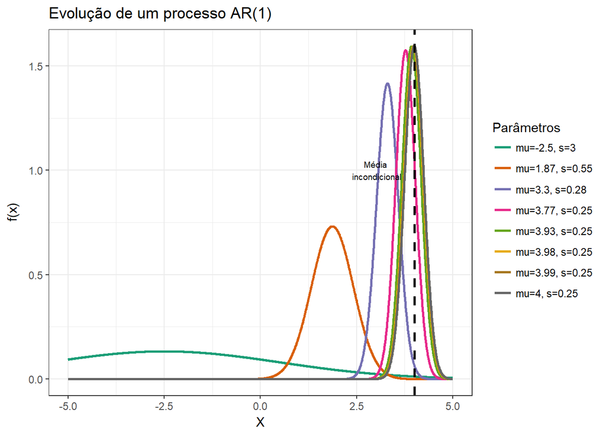

```r
# Parâmetros iniciais da cadeia
mu0     <- -2.5
sigma20 <- 3

# Cria os paranauês
nite <- 50 # número de iterações - sugiro não mudar pois os laços for estão programados considerando nite = 50
x    <- as.vector(rep(NA,nite))
x0   <- 0
x[1] <- a + b*x0 + d*rnorm(1)
mu        <- as.vector(rep(NA,nite))
sigma2    <- as.vector(rep(NA,nite))
mu[1]     <- mu0
sigma2[1] <- sigma20

# Itera
for (i in 2:nite){
  x[i]      <- a + b*x[i-1] + d*rnorm(1)
  mu[i]     <- a + b*mu[i-1]
  sigma2[i] <- b^2*sigma2[i-1] + d^2
}

# Agora vamos criar um grid
eixox <- seq(-5, 5, 0.005)
dens  <- data.frame(rep(NA, length(eixox)),rep(NA, length(eixox)),rep(NA, length(eixox)),rep(NA, length(eixox)),rep(NA, length(eixox)),rep(NA, length(eixox)),rep(NA, length(eixox)),rep(NA, length(eixox)),rep(NA, length(eixox)),rep(NA, length(eixox)))

# Vamos usar 10 densidades apenas para o gráfico
for (i in 1:10){
  dens[,i] <- dnorm(eixox, mean=mu[(1+(i-1)*5)], sd = sigma2[(1+(i-1)*5)])
}

dens <- data.frame(eixox, dens)
colnames(dens) <- c("X",
                    paste0("mu=",round(mu[1],2), ", s=", round(sigma2[1],2)),
                    paste0("mu=",round(mu[6],2), ", s=", round(sigma2[6],2)),
                    paste0("mu=",round(mu[11],2), ", s=", round(sigma2[11],2)),
                    paste0("mu=",round(mu[16],2), ", s=", round(sigma2[16],2)),
                    paste0("mu=",round(mu[21],2), ", s=", round(sigma2[21],2)),
                    paste0("mu=",round(mu[26],2), ", s=", round(sigma2[26],2)),
                    paste0("mu=",round(mu[31],2), ", s=", round(sigma2[31],2)),
                    paste0("mu=",round(mu[36],2), ", s=", round(sigma2[36],2)),
                    paste0("mu=",round(mu[41],2), ", s=", round(sigma2[41],2)),
                    paste0("mu=",round(mu[46],2), ", s=", round(sigma2[46],2)))

df1   <- melt(dens, id.vars="X")

# Agora plotamos o gráfico
p <- ggplot(df1, aes(X,value, color = factor(variable))) +
  geom_line(size = 1)+
  scale_x_continuous(name = TeX("$X$")) +
     scale_y_continuous(name = TeX("$f(x)$")) +
  ggtitle("Evolução de um processo AR(1)") +
    scale_colour_brewer(palette="Dark2") +
    labs(colour = "Parâmetros") +
  theme_bw()

p <- p + geom_vline(aes(xintercept=muinf),
            color="black", linetype="dashed", size=1) + annotate("text", x = muinf-1, y = 1, label = paste0("Média\n incondicional"), size = 2.5)

p
```

```r
# Altura e largura são em inches, default = 7
pdf(file="C:\\Users\\Aishameriane\\OneDrive\\Documentos\\Mestrado Economia\\Bayesiana - 2018-01\\Notas de Aula 2018\\Imagens notas de aula\\Cap 4\\Fig-4.008.pdf", width = 7, height = 3)
p
dev.off()
```

# MCMC

## Introdução

Até o momento, estudamos o método de Monte Carlo com o foco de obter valores i.i.d. de uma densidade de interesse $f$, tanto de maneira direta, como de maneira indireta (via amostragem por importância). Agora iremos mudar o foco para métodos que geram uma amostra *correlacionada* de valores a partir de uma Cadeia de Markov (do inglês *Markov Chain*). A teoria de processos estocásticos (mais especificamente, as propriedades de cadeias de Markov) pode ser explorada para obter densidades candidatas mesmo quando um amostrador por importância não é facilmente encontrado. Mais especificamente, métodos de MCMC colocam poucos ``requisitos’’ nas densidades candidatas $f$, mesmo quando não conseguimos encontrar um amostrador por importância de maneira fácil. Além disso, pode-se dividir um problema de alta dimensão em vários pequenos problemas de menor dimensão, tornando o processo mais eficiente (C. Robert and Casella 2010)

Métodos de Cadeias de Markov via Monte Carlo (MCMC) foram introduzidos na econometria por volta de 1990, após serem desenvolvidos na estatística. Um dos motivos para o sucesso da técnica nos trabalhos de econometria bayesiana é sua facilidade de uso em comparação com a amostragem por importância. Apesar de ser um método de redução de variância de MC, IS torna-se pouco apelativo pois é uma técnica que se ajusta pontualmente aos problemas: é necessário encontrar uma boa aproximação para a densidade a posteriori e um amostrador por importância de uma aplicação (seja por causa de um modelo ou até mesmo um determinado conjunto de dados) pode não servir para outras aplicações. Os métodos de MCMC, por outro lado, se mostram mais fácil de implementar sem a necessidade de despender tanto tempo procurando pelas densidades candidatas (Bauwens, Lubrano, and Richard 2000).

Por não imporem muitas restrições nas densidades candidatas, os métodos de MCMC tem ampla aplicabilidade. No entando, sua performance é bastante variável e depende da complexidade do problema que se quer resolver. Intuitivamente o método consiste em produzir aproximações para integrais e outras quantidades de interesse a partir de uma Cadeiade Markov $\{\theta^{(t)}\}$ cuja distribuição limite é exatamente a densidade que temos interesse. Esta ideia de utilizar o comportamento assintótico de uma cadeia de Markov surgiu mais ou menos na mesma época do primeiro algorítmo de Monte Carlo, porém não havia recursos computacionais suficientes na época que permitissem sua disseminação (C. P. Robert 2007).

Os métodos de MCMC mais conhecidos são o *amostrador de Gibbs* (do inglês *Gibbs Sampler*) e o algoritmo de *Metropolis-Hastings* (MH), sendo que este último se relaciona com amostragem por importância. Ambos métodos podem ser combinados, dando origem ao *Metropolis within Gibbs*, para o caso onde não é possível implementar um amostrador de Gibbs sozinho. Uma vez que são métodos de MCMC, eles são baseados na geração de amostras da posteriori que não são independentes entre si (Bauwens, Lubrano, and Richard 2000).

## Ideias básicas

Na seção de integração de Monte Carlo apresentamos o problema de aproximar a integral
$$\int h(x)f(x)dx.$$
A nossa estratégia até então era enxergar a integral como uma esperança populacional para aproximá-la por uma média amostral. Nos casos onde o suporte comum de $h(x)$ e $f(x)$ é pequeno, podemos escolher um amostrador por importância que vai atuar fazendo o papel de ``pesos’’ para que as amostras geradas estejam dentro do intervalode interesse com uma probabilidade um pouco maior (método da amostragem por importância). Mesmo assim, nem sempre iremos conseguir estimativas boas, seja pela falta de um suporte comum seja pela dificuldade em escolher um bom amostrador por importância.

O que iremos discutir agora é como aproximar a integral fazendo a escolha de um núcleo de transição cuja distribuição estacionária é a distribuição alvo que temos interesse. Vimos nas seções anteriores as condições para as quais é possível que uma cadeia de Markov convirja para sua densidade estacionária, isto é, para um valor inicial $x_0$, uma cadeia $\{X_t \}$ é gerada utilizando um núcleo de transição $K$ (ou $P$) com distribuição estacionária $f$ (ou $\pi$), e sob determinadas condições, a convergência de $\{X_t \}$ para uma v.a. que foi amostrada diretamente de $f$ está garantida pelos resultados anteriores.

**Definição (Método de Cadeias de Markov via Monte Carlo)** Um método de MCMC para a simulação da distribuição $f$ é qualquer método que produza uma cadeia de Markov ergódica cuja distribuição estacionária é $f$.

(Chib 2013) Das seções anteriores, vimos que a característica marcante das cadeias de Markov é que seu estado atual depende exclusivamente do estado que a cadeia encontra-se no momento anterior, isto é, para uma cadeia $\{\theta^{(t)} \}_{t \geq 0}$, a distribuição de $\theta^{(t+1)}$ dado o valor atual e os valores passados da cadeia, depende apenas de $\theta^{(t)}$. Essa probabilidade é representada pelo núcleo de transição
$$K(\theta^{(t)}, A | y) = \mathbb{P}(\theta^{(t+1)} \in A| y, \theta^{(t)})$$
em que $A$ é um conjunto mensurável da $\sigma$-álgebra onde a posteriori $\pi(\theta|y)$ está definida. O que queremos fazer então é encontrar um Kernel $K(\theta, A|y$ tal que a probabilidade de que a cadeia esteja no conjunto $A$ dada uma condição inicial $\theta^(0)$ convirja para a densidade algo que temos interesse. Mais especificamente, queremos que
$$K^{(t)}(\theta^{(0)}, A|y) = \mathbb{P}(\theta^{(t)} \in A| y, \theta^{(0)})$$
convirja, quando $t$ for suficientemente grande, para a probabilidade que a distribuição alvo atribui a $A$ ocorrer. Uma vez que o núcleo $K$ está definido, pode-se obter retiradas da seguinte forma:

$$\begin{align*}
\theta^{(1)} &\sim K(\theta^{(0)}, \cdot|y)\\
\theta^{(2)} &\sim K(\theta^{(1)}, \cdot|y)\\
& \vdots\\
\theta^{(t+1)} &\sim K(\theta^{(t)}, \cdot|y)\\
& \vdots
\end{align*}$$

Uma vez que a cadeia foi construída de forma a ter distribuição invariante igual a $\pi(\theta|y)$, os valores a partir de um certo $n_0$, $\{\theta^{(n_0 + t)} \}_{t =1}^{T}$ poderão ser considerados valores amostrados a partir da posteriori (para $n_0$ suficientemente grande). Já as observações iniciais, $\{\theta^{(t)} \}_{t=0}^{T}$ são conhecidas como *burn in* e descartadas. Se de fato $n_0$ é grande e se $T$ também for grande, podemos construir uma sequência de valores simulados e combinar com o método de Monte Carlo para poder calcular momentos da distribuição a posteriori.

Apesar de serem métodos mais flexíveis que os métodos de integração de Monte Carlo, os métodos de MCMC requerem cautela na hora de sua implementação. (Chib 2013) chama atenção para o fato de que não existe um único Kernel dada uma distribuição alvo, sendo que, dentre os núcleos possíveis de serem usados, alguns produzirão amostras da densidade estacionária de maneira mais (ou menos) eficiente, em particular quando as amostras são altamente correlacionadas (fazendo com que não seja explorado todo o suporte da densidade que temos interesse).

# Referências

Bauwens, Luc, Michel Lubrano, and Jean-Francois Richard. 2000. *Bayesian Inference in Dynamic Econometric Models*. OUP Oxford.

Chib, Siddhartha. 2001. “Markov Chain Monte Carlo Methods: Computation and Inference.” In *Handbook of Econometrics*, 5:3569–3649. Elsevier.

———. 2013. “Introduction to Simulation and MCMC Methods.” In *The Oxford Handbook of Bayesian Econometrics*, edited by John Geweke, Gary Koop, and Herman Van Dijk, 183–217. Oxford: Oxford University Press.

Greenberg, Edward. 2008. *Introduction to Bayesian Econometrics*. Cambridge University Press.

Karlin, Samuel, and Howard Taylor. 1975. *A First Course in Stochastic Processes*. Academic press.

Meyn, Sean P, and Richard L Tweedie. 2012. *Markov Chains and Stochastic Stability*. Springer Science & Business Media.

Paulino, Carlos Daniel Mimoso., Turkman M. Antónia Amaral., and Bento Murteira. 2003. *Estatística Bayesiana*. Fundação Calouste Gulbenkian.

Robert, Christian P. 2007. *The Bayesian Choice: From Decision-Theoretic Foundations to Computational Implementation*. Springer.

Robert, Christian, and George Casella. 1999. *Monte Carlo Statistical Methods*. Springer.

———. 2010. *Introducing Monte Carlo Methods with R*. Vol. 18. Springer.